# Practical ML Final Markdown

Tony Kwang Hyun Kim

11/19/2020

### Overview:

Using devices such as Jawbone Up, Nike FuelBand, and Fitbit it is now possible to collect a large amount of data about personal activity relatively inexpensively. These type of devices are part of the quantified self movement – a group of enthusiasts who take measurements about themselves regularly to improve their health, to find patterns in their behavior, or because they are tech geeks. One thing that people regularly do is quantify how much of a particular activity they do, but they rarely quantify how well they do it. In this project, I will use data from accelerometers on the belt, forearm, arm, and dumbell of 6 participants. They were asked to perform barbell lifts correctly and incorrectly in 5 different ways. More information is available from the website here: http://web.archive.org/web/20161224072740/http:/groupware.les.inf.puc-rio.br/har.

### Data Setup:

Packages Used:

```r
library(knitr)
library(caret)
library(Hmisc)
```

```r
library(ggplot2)
library(rpart)
library(rpart.plot)
library(rattle)
library(randomForest)
```

Data Retrieval:

```r
#URL
trainingUrl <- "https://d396qusza40orc.cloudfront.net/predmachlearn/pml-training.csv"

testingUrl <- "https://d396qusza40orc.cloudfront.net/predmachlearn/pml-testing.csv"

#Downloading the datasets
training <- read.csv(url(trainingUrl))
testing <- read.csv(url(testingUrl))
dim(training); dim(testing)
```

```
## [1] 19622   160
```

```
## [1]  20 160
```

Splitting Data:

```r
set.seed(1111)
inTrain <- createDataPartition(training$classe, p = .6, list = F)
trainData <- training[inTrain,]
testData <- training[-inTrain,]
dim(trainData); dim(testData)
```

```
## [1] 11776   160
```

```
## [1] 7846  160
```

Removing Zero Variance Variables

```r
nzv <- nearZeroVar(trainData)

trainData <- trainData[,-nzv]
testData <- testData[,-nzv]
dim(trainData);dim(testData)
```

```
## [1] 11776   107
```

```
## [1] 7846  107
```

Removing Identifer Information

```r
trainData <- trainData[,-c(1:5)]
testData <- testData[,-c(1:5)]
dim(trainData);dim(testData)
```

```
## [1] 11776   102
```

```
## [1] 7846  102
```

```r
length(which((colSums(is.na(trainData))/11776)>.05))
```

```
## [1] 48
```

```r
length(which((colSums(is.na(trainData))/11776)>.1))
```

```
## [1] 48
```

```r
length(which((colSums(is.na(trainData))/11776)>.2))
```

```
## [1] 48
```

```r
NaCols <- which((colSums(is.na(trainData))/11776)>.05)

trainData <- trainData[,-NaCols]
testData <- testData[,-NaCols]
dim(trainData);dim(testData)
```

```
## [1] 11776    54
```

```
## [1] 7846   54
```

After removing all variables with near zero variance, no relevance to prediction, and variables with only NA values, we are left with 54 variables.

### Decision Tree Model

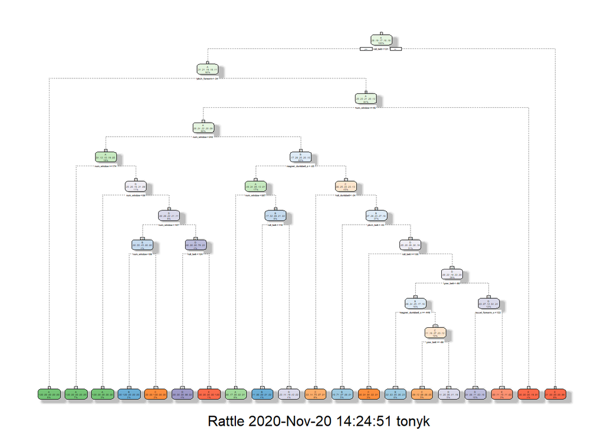

```r
DecTreeMod <- rpart(classe ~ ., data=trainData, method="class")
fancyRpartPlot(DecTreeMod)
```

```r
DecTreePred <- predict(DecTreeMod, newdata = testData, type = "class")
confusionMatrix(DecTreePred, factor(testData$classe))
```

```
## Confusion Matrix and Statistics
##
##           Reference
## Prediction    A    B    C    D    E
##          A 1897  112    5   30    7
##          B  127 1091   64   74  124
##          C   55  154 1097   75   36
##          D  146  146  178 1027  227
##          E    7   15   24   80 1048
##
## Overall Statistics
##
##                Accuracy : 0.7851
##                  95% CI : (0.7759, 0.7942)
##     No Information Rate : 0.2845
##     P-Value [Acc > NIR] : < 2.2e-16
##
##                   Kappa : 0.7294
##
##  Mcnemar's Test P-Value : < 2.2e-16
##
## Statistics by Class:
##
##                      Class: A Class: B Class: C Class: D Class: E
## Sensitivity            0.8499   0.7187   0.8019   0.7986   0.7268
## Specificity            0.9726   0.9385   0.9506   0.8938   0.9803
## Pos Pred Value         0.9249   0.7372   0.7742   0.5957   0.8927
## Neg Pred Value         0.9422   0.9329   0.9578   0.9577   0.9409
## Prevalence             0.2845   0.1935   0.1744   0.1639   0.1838
## Detection Rate         0.2418   0.1391   0.1398   0.1309   0.1336
## Detection Prevalence   0.2614   0.1886   0.1806   0.2197   0.1496
## Balanced Accuracy      0.9112   0.8286   0.8763   0.8462   0.8535
```

Accuracy of .7851, out of sample error estimate to around .22

### Random Forest Model

```r
RanForMod <- randomForest(factor(classe) ~ ., data = trainData)
print(RanForMod)
```

```
##
## Call:
##  randomForest(formula = factor(classe) ~ ., data = trainData)
##                Type of random forest: classification
##                      Number of trees: 500
## No. of variables tried at each split: 7
##
##         OOB estimate of  error rate: 0.31%
## Confusion matrix:
##      A    B    C    D    E  class.error
## A 3347    0    0    0    1 0.0002986858
## B    7 2270    2    0    0 0.0039491005
## C    0    6 2047    1    0 0.0034079844
## D    0    0   14 1914    2 0.0082901554
## E    0    0    0    4 2161 0.0018475751
```

```r
RanForPred <- predict(RanForMod, testData, type = "class")
confusionMatrix(RanForPred, factor(testData$classe))
```

```
## Confusion Matrix and Statistics
##
##           Reference
## Prediction    A    B    C    D    E
##          A 2231    5    0    0    0
##          B    1 1513    7    0    0
##          C    0    0 1361    3    0
##          D    0    0    0 1282    0
##          E    0    0    0    1 1442
##
## Overall Statistics
##
##                Accuracy : 0.9978
##                  95% CI : (0.9965, 0.9987)
##     No Information Rate : 0.2845
##     P-Value [Acc > NIR] : < 2.2e-16
##
##                   Kappa : 0.9973
##
##  Mcnemar's Test P-Value : NA
##
## Statistics by Class:
##
##                      Class: A Class: B Class: C Class: D Class: E
## Sensitivity            0.9996   0.9967   0.9949   0.9969   1.0000
## Specificity            0.9991   0.9987   0.9995   1.0000   0.9998
## Pos Pred Value         0.9978   0.9947   0.9978   1.0000   0.9993
## Neg Pred Value         0.9998   0.9992   0.9989   0.9994   1.0000
## Prevalence             0.2845   0.1935   0.1744   0.1639   0.1838
## Detection Rate         0.2843   0.1928   0.1735   0.1634   0.1838
## Detection Prevalence   0.2850   0.1939   0.1738   0.1634   0.1839
## Balanced Accuracy      0.9993   0.9977   0.9972   0.9984   0.9999
```

Accuracy of .9978, out of sample estimating near to 0.

### Applying Random Forest Model to Test Data

```r
predict(RanForMod, newdata = testing)
```

```
##  1  2  3  4  5  6  7  8  9 10 11 12 13 14 15 16 17 18 19 20
##  B  A  B  A  A  E  D  B  A  A  B  C  B  A  E  E  A  B  B  B
## Levels: A B C D E
```